# PM2.5

Fernando Hold Montaguti

04/01/2020

## Análsie de Dados

Com a base PM2.5 onde foram observados 420768 registros dentro de 5 anos a respeito de poluentes e particulados no ar dentro de algumas estações da China, além de informações como temperatura, direção do vento, pressão, precipitação de chuva, etc. Foram realizadas algumas análises para entender o comportamento dos dados.

Primeiramente tomou-se como fator a estação de origem para verificar como que os poluentes estavam alocados geograficamente. A medida de referência foi a mediana para a concentração dos poluentes, uma vez que não possui tanta interferência de medidas extremas.

```
## # A tibble: 12 x 7
##    station       PM2.5  PM10   SO2   NO2    CO    O3
##    <fct>         <dbl> <dbl> <dbl> <dbl> <dbl> <dbl>
##  1 Aotizhongxin     58    87     9    53   900  42
##  2 Changping        46    72     7    36   800  46
##  3 Dingling         41    60     5    19   600  61
##  4 Dongsi           61    86    10    47  1000  44.1
##  5 Guanyuan         59    89     8    51   900  41
##  6 Gucheng          60    99     7    50   900  45
##  7 Huairou          47    69     4    25   800  49
##  8 Nongzhanguan     59    85     9    51   900  45
##  9 Shunyi           55    77     5    37   800  43
## 10 Tiantan          59    85     7    47   900  40
## 11 Wanliu           59    88    10    60   900  32
## 12 Wanshouxigong    60    91     8    49  1000  42
```

Nota-se que não existe uma distinção muito clara em cada estação, sendo que cada poluente se sobressai em alguns aspectos dentro das estações.

Como existem registros em um grande período de tempo, verificou-se o comportamento dos poluentes ao longo dos anos, sendo retratados novamente pela sua mediana.

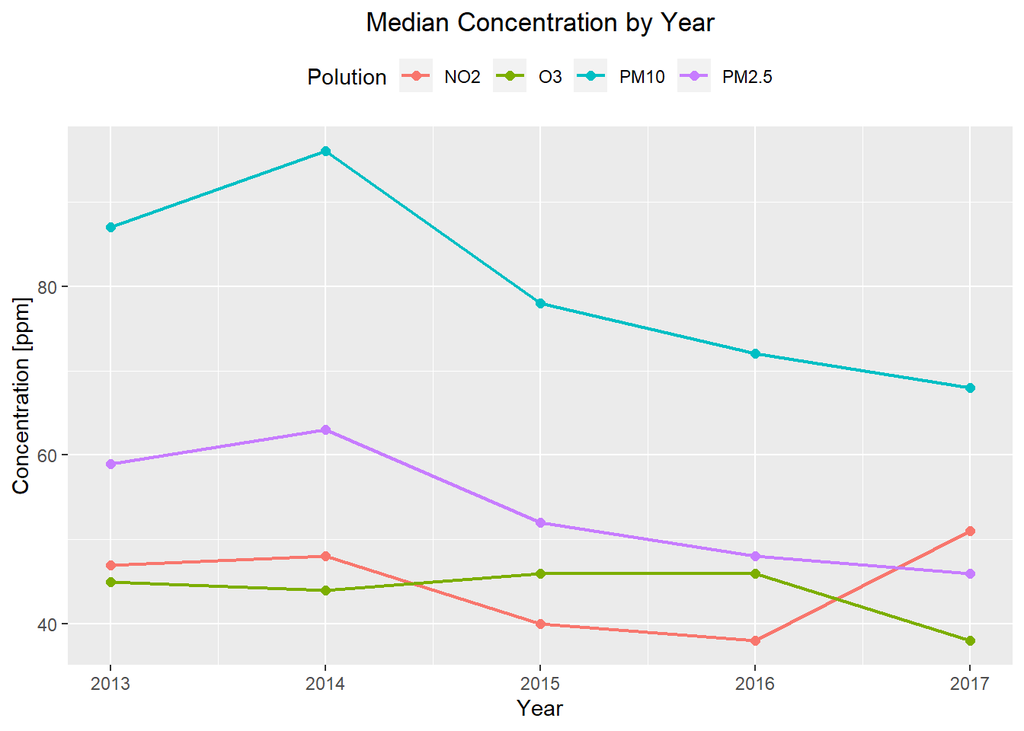

Logo após foram analisados as medidas de posição e disperção dos poluentes, sendo apresentados conforme tabela abaixo.

```
##      PM2.5    PM10     SO2      NO2      CO       O3
## Min  2        2        0.2856   1.0265   100      0.2142
## Q1   20       36       3        23       500      11
## Q2   55       82       7        43       900      45
## Q3   111      145      20       71       1500     82
## Max  999      999      500      290      10000    1071
## Mean 79.79343 104.6026 15.83083 50.63859 1230.766 57.37227
## SD   80.82239 91.77243 21.6506  35.12791 1160.183 56.66161
## VAR  6532.259 8422.178 468.7486 1233.97  1346024  3210.538
```

Uma análise de correlaçlão também foi realizada entre os dados registrados, para verificar a influência de uma variável sobre a outra. Seu resultado foi apresentado em uma matrix de correlação envolvendo 11 das 17 variáveis do Dataset.

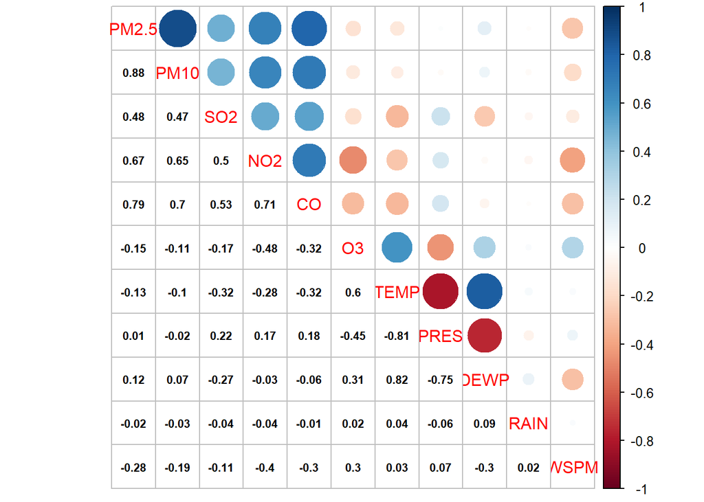

Para se realizar um modelo preditivo de concentração de PM2.5 com base em outras variáveis, utilizou-se as de maior correlação encontrada. Envolvendo 5 variáveis de maior correlação, os dados do modelo podem ser observados abaixo.

```
##
## Call:
## lm(formula = PM2.5 ~ PM10 + SO2 + NO2 + CO + WSPM, data = Data)
##
## Residuals:
##     Min      1Q  Median      3Q     Max
## -510.72  -13.01    0.44   13.20  678.20
##
## Coefficients:
##               Estimate Std. Error t value Pr(>|t|)
## (Intercept)  0.0719776  0.1428588   0.504    0.614
## PM10         0.5745690  0.0008381 685.548  < 2e-16 ***
## SO2          0.0187264  0.0029218   6.409 1.46e-10 ***
## NO2         -0.0151640  0.0023177  -6.543 6.05e-11 ***
## CO           0.0217148  0.0000719 302.021  < 2e-16 ***
## WSPM        -4.0076853  0.0456811 -87.732  < 2e-16 ***
## ---
## Signif. codes:  0 '***' 0.001 '**' 0.01 '*' 0.05 '.' 0.1 ' ' 1
##
## Residual standard error: 31.82 on 388713 degrees of freedom
##   (32049 observations deleted due to missingness)
## Multiple R-squared:  0.8429, Adjusted R-squared:  0.8429
## F-statistic: 4.172e+05 on 5 and 388713 DF,  p-value: < 2.2e-16
```

R² ajustado possui um valor de 0,8429 ajustando grande parte das observações, também apresenta um baixo valor de resíduos. Para auxílio da análise do modelo, plotou-se suas características.

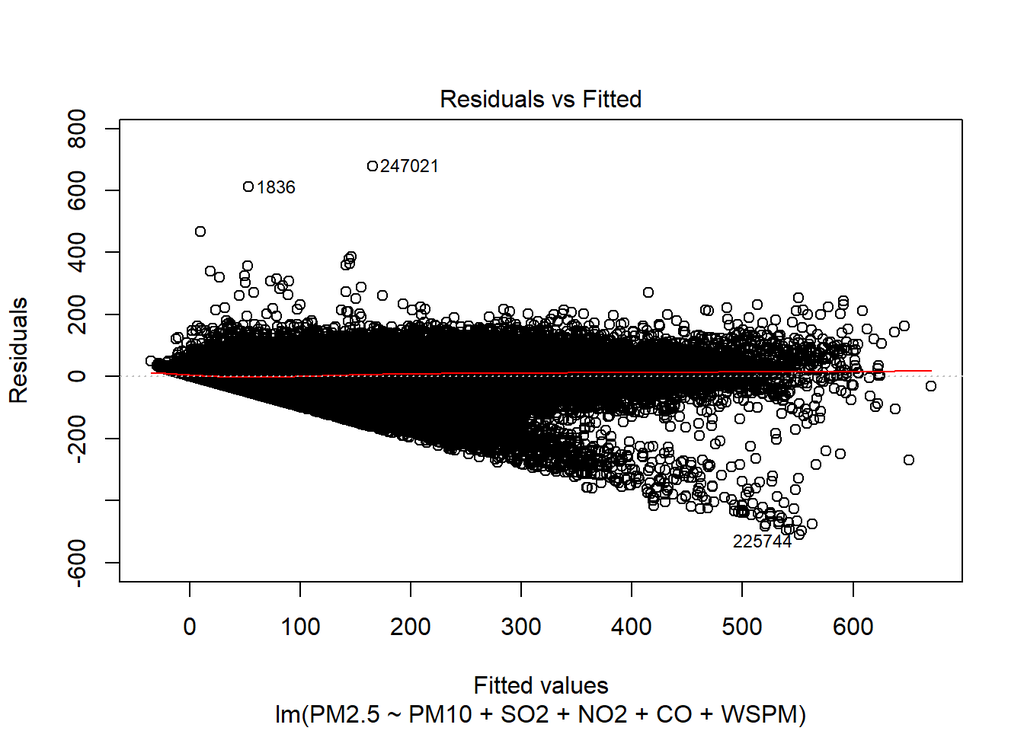

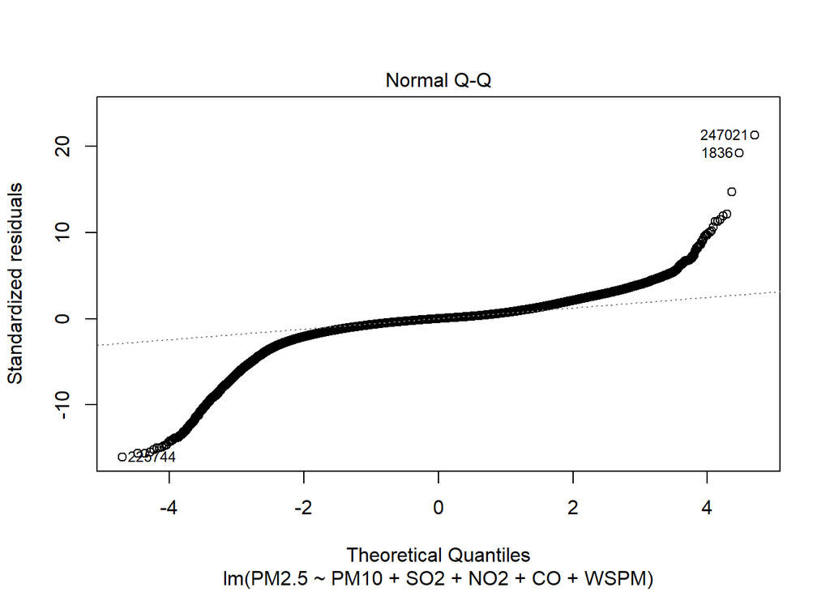

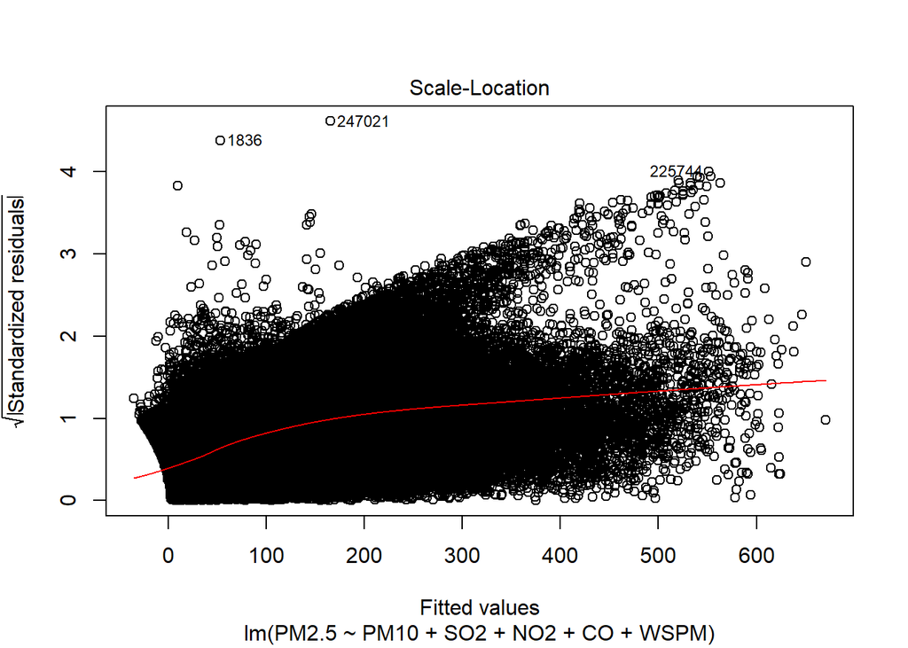

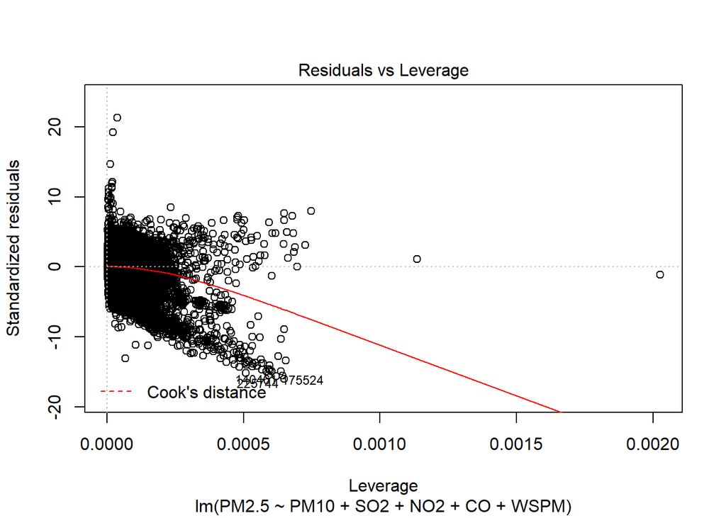

Como esperado, grande parte dos dados se ajusta com a equação obtida do modelo.

[PM2.5] = 0.5745690[PM10]+0.0187264[SO2]-0.0151640[NO2]+0.0217148[CO]-4.0076853[WSPM]

O intervalo de confiança de cada variável também pode ser obtivo de acordo com tabela apresentada.

```
##                   2.5 %      97.5 %
## (Intercept) -0.20802126  0.35197653
## PM10         0.57292631  0.57621168
## SO2          0.01299978  0.02445306
## NO2         -0.01970656 -0.01062135
## CO           0.02157386  0.02185570
## WSPM        -4.09721883 -3.91815172
```